# Descriptive and Exploratory Analysis of Crypto Dataset

# Correlation of Crypto Assets compared to Bitcoin

In the crypto market, BTC has a special position and in the minds of market participants often represents the entire crypto universe. The assumption being that all (or at least the ones which do not have an underlying value or are bound to such, e.g. the TUSD coin which has a 1:1 binding to the USD value) crypto assets correlate with BTC. To check this hypothesis, the correlation factors for all top 50 crypto assets against BTC shall be investigated.

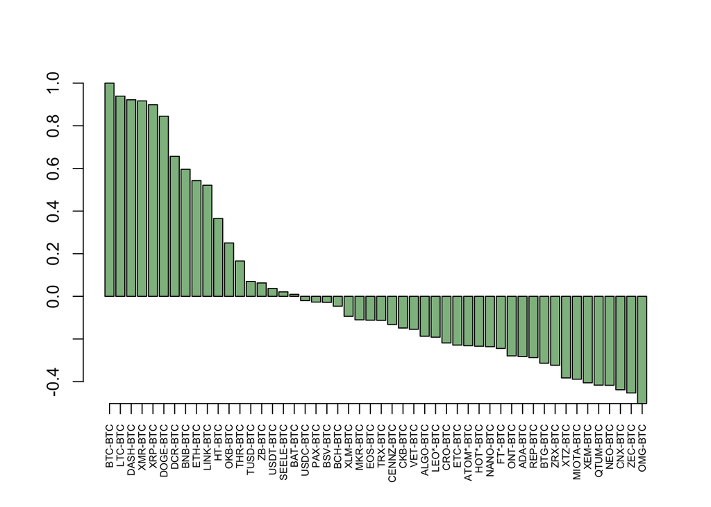

```r
corr_coef_BTC <- list()
for ( crypto in top50.ts$keys()){
    corr_coef_BTC[[paste(crypto,'-BTC', sep='')]] <- cor(x=as.numeric(window(top50.ts$get(crypto),   #using window() here to create an equal-sized subset of the complete time-series since not all of them have the same number of observations.
                                                                  start=c(2016,1),
                                                                  end=c(2019,5))),
                                y=as.numeric(window(top50.ts$get('BTC'),start=c(2016,1),end=c(2019,5))),
                                use='everything',
                                method='pearson')

}
# Unlisting above list
btc.coef <- unlist(corr_coef_BTC)

# barplot of sorted correlation coefficients
midpts<-barplot(btc.coef[order(btc.coef, decreasing=TRUE)], xaxt='n', col='darkseagreen' )
axis(1, at=midpts,labels=names(btc.coef[order(btc.coef, decreasing=TRUE)]), las=2, cex.axis=0.6)
```

It would appear that the correlation coefficient (Pearson correlation) between the 49 top crypto currencies and bitcoin is quite significant. Surprisingly, most crypto assets show a negative correlation compared to BTC (32 / 49). Those negative correlations are less pronounced then the present positive correlations though (smaller absolute value of correlation coefficient). When we apply the “significance” threshold for correlation analysis (+/- 0.7), we find that only 5 crypto assets - other than BTC itself - show a ‘high’ correlation to BTC. It is worth noting here, that ETH is **not** part of the assets which are highly correlated with BTC.

```r
btc.coef[abs(btc.coef) >= 0.7]
```

```
##   BTC-BTC   XRP-BTC   LTC-BTC   XMR-BTC  DASH-BTC  DOGE-BTC
## 1.0000000 0.8989781 0.9391586 0.9166745 0.9221461 0.8450320
```

# Decomposition and Seasonality

We have initially already prepared the decomposed versions of the time series object of the top 50 assets, procured via the API. We will now have a closer look a the aspects of the decompositions of the time series, their seasonal and trend aspects as well as the random remainder.

Bringing back the initial decomposition of ETH, we can already observe a few facts:

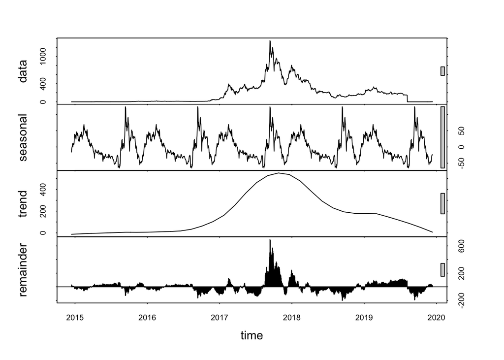

```r
plot(top50$get('ETH'))
```

Comparing the decomposed plot of ETH to the same of BTC, we can see a certain overlap of seasonality, which at the same time inspired the initial idea of this paper:

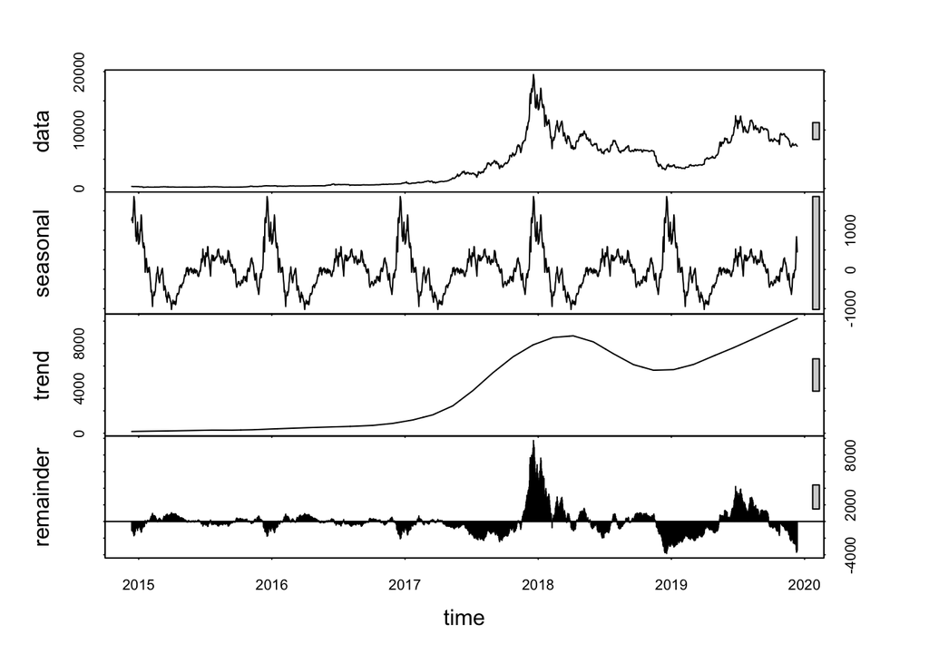

```r
plot(top50$get('BTC'))
```

One key aspect of this working paper will be to highlight common seasonal patterns across the selected top 50 assets which will be presented in the second markdown file calle ‘Analysis_of_Seasonality.Rmd’.